# danjtan_4

Dan Tanner

February 2, 2017

# Exercise 1

First we calculate the means for each of the four subsets:

```r
mean(CO2$uptake[CO2$Treatment == "nonchilled"])
```

```
## [1] 30.64286
```

```r
mean(CO2$uptake[CO2$Treatment == "chilled"])
```

```
## [1] 23.78333
```

```r
mean(CO2$uptake[CO2$Type == "Quebec"])
```

```
## [1] 33.54286
```

```r
mean(CO2$uptake[CO2$Type == "Mississippi"])
```

```
## [1] 20.88333
```

Next we calculate the grand mean:

```r
gm = mean(CO2$uptake)
print(gm)
```

```
## [1] 27.2131
```

To find the effect of each group, we calculate the difference betweein the group mean and the grand mean:

```r
mean(CO2$uptake[CO2$Treatment == "nonchilled"]) - gm
```

```
## [1] 3.429762
```

```r
mean(CO2$uptake[CO2$Treatment == "chilled"]) - gm
```

```
## [1] -3.429762
```

```r
mean(CO2$uptake[CO2$Type == "Quebec"]) - gm
```

```
## [1] 6.329762
```

```r
mean(CO2$uptake[CO2$Type == "Mississippi"]) - gm
```

```
## [1] -6.329762
```

Now we can check that these are the same numbers given by the effects table:

```r
model.tables(CO2.aov, "effects", se=FALSE)
```

```
## Tables of effects
##
##  Treatment
## Treatment
## nonchilled    chilled
##       3.43      -3.43
##
##  Type
## Type
##      Quebec Mississippi
##        6.33       -6.33
```

So, interpreting these effects figures, we see that Treatment has a smaller effect on the mean than the location (“Type”), since the magnitude of the differences from the mean is larger for the “Type” groups than for the “Treatment” groups.

# Exercise 2

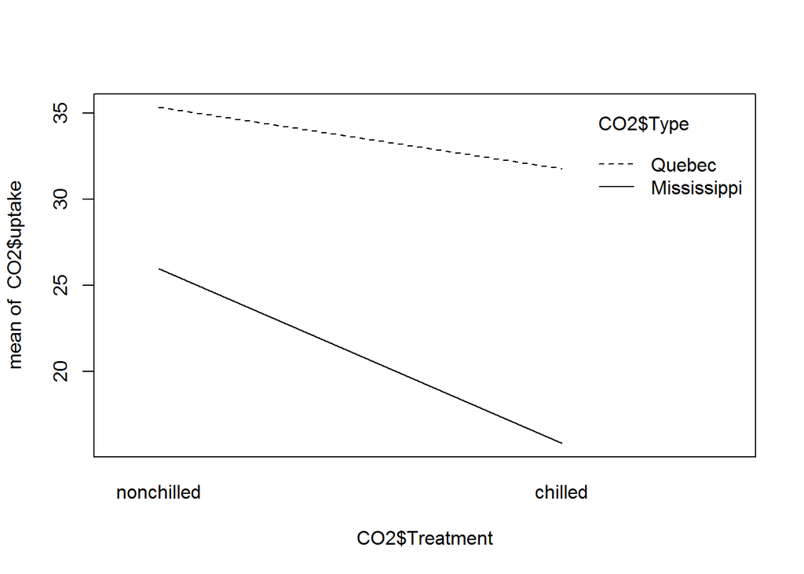

```r
interaction.plot(CO2$Treatment, CO2$Type, CO2$uptake)
```

We can see that there is potentially a significant interaction between “Treatment” and “Type” because the lines are not quite parallel in the interaction plot above. Thus we include an interaction term in out linear model:

```r
CO2.lm = lm(uptake~Treatment + Type + Treatment*Type, data=CO2)
anova(CO2.lm)
```

```
## Analysis of Variance Table
##
## Response: uptake
##                Df Sum Sq Mean Sq F value    Pr(>F)
## Treatment       1  988.1   988.1 15.4164 0.0001817 ***
## Type            1 3365.5  3365.5 52.5086 2.378e-10 ***
## Treatment:Type  1  225.7   225.7  3.5218 0.0642128 .
## Residuals      80 5127.6    64.1
## ---
## Signif. codes:  0 '***' 0.001 '**' 0.01 '*' 0.05 '.' 0.1 ' ' 1
```

We can see from the “Treatment:Type” row that we get a p-value of 0.064, so requiring 95% confidence we cannot conclude that there is a significant itneraction between the two independant variables. We do, however, see significant effects of both the Treatment (p = 0.0001817) and Type (p = 2.378e-10).